# Minimax Series Simulations

### Motivation

This project discusses nonparametric density estimation under a special type of sparsity condition, the **approximate sparsity**.

Suppose $X$ is an economic variable of interest and we want to estimate its probability density $f_X$. In particular, $f_X$ has a series representation $$ f_X(x) = \sum_{j=1}^\infty \theta_j\phi_j(x),\quad \theta_j = E[\phi_j(X)] $$ where $\{\phi_j\}$ is an orthonormal basis, choosing by researcher.

Given data $\{X_i\}_{i=1}^N$, we can estimate $$ \hat{f}_J(x) = \sum_{j=1}^J \hat{\theta}_j\phi_j(x),\quad \hat{\theta}_j = \frac{1}{n}\sum_{i=1}^n \phi_j(X_i) $$

The main question is how to choose the series cutoff $J$, which governs the variance-bias tradeoff.

Since the true coefficients $\theta_j = E[\phi_j(X)]$ are expectations, this framework essentially estimates many expectations. Recent high-dimensional econometrics literature provides one method of choosing the optimal cutoff $J$ in a data-driven way, which relies on LASSO.

### Approximate Sparsity

In particular, LASSO has been shown to work well when you have sparse coefficients, and in fact, it still works when the sparsity only holds approximately. Using our density $f_X(x) = \sum_{j=1}^\infty\theta_j\phi_j(x)$ for example.

- sparsity will require all but finitely many coefficients $\theta_j$'s being zero
- this is not particularly realistic in many settings, especially in the density setting
- approximate sparsity assumes that $\theta_j$'s don't have to be exactly zero, but instead $|\theta_j|\lesssim j^{-\alpha}$ for some constant $\alpha$.
- in addition, approximate sparsity allows this condition to hold with **reordering**, that is, we can be agnostic about which coefficients are more important a priori.

### Contribution

In my paper, I establish the complexity of the function classes that are characterized by the approximate sparsity condition, and demonstrate that LASSO as a selection mechanism produces the optimal estimator for the densities in these classes. This has implications for both density estimation and nonparametric regression problem.

### Code

Below is the Python code corresponding to the theory in my paper. A few highlights:

- We use cosine basis for illustration. In practice can use any orthonormal basis depending on the application;
- We essentially creates a data-driven threshold $\hat{\lambda}$, and select all the estimated coefficients $\hat{\theta}_j$'s with (absolute) magnitude above this threshold, while penalize the rest to zero;
- This data-driven threshold is coded out exactly as the theory suggested in my paper;
- The resulting estimator is then post-processed via P-Algorithm, which performs a very efficient projection to guarantee that the final estimator is a proper density.

```python
import pandas as pd
import numpy as np
import matplotlib.pyplot as plt
from scipy.stats import beta
from scipy.stats import norm # for normal cdf
from scipy.integrate import quad  # for numerical integration
import warnings
import time
from numpy.random import random
from scipy import interpolate
```

## Target Density

```python
# cos_series function serves two purposes:
# 1. to create the target density
# 2. to generate estimators

def cos_series(x,t,z):
    sum = t[0]*1
    for j in range(1,z):
        sum = sum + t[j]*(2**0.5)*np.cos((np.pi)*j*x)
    return sum
```

```python
# target specifies the series coefficients for the target density
# A is the constant that we need to adjust to make sure the density we construct is positive.

A = 2
target = np.asarray([1, A*(2**(-2)), A*(3**(-2)), 0, A*(10**(-2)), 0, A*(7**(-2)), A*(8**(-2)),0,0, A*(4**(-2)), 0, A*(6**(-2)), A*(5**(-2)), A*(9**(-2))])
```

```python
# create our target density
def f(x):
    return cos_series(x,target,15)
```

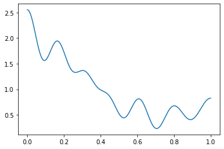

```python
# plot this function, see if it works
x = np.linspace(0,1,10000)
y = f(x)
plt.plot(x,y)
plt.show()

# yes! it's positive and integrate to one since its first Fourier coefficients = 1.
```

## Random Sample Generator From Target Density

```python
# part1: get the approximated inverse cdf using interpolation

def sample(g):
    x = np.linspace(0,1,100000, endpoint = True)    # change this depending on the domain of your density
    y = g(x)                        # probability density function, pdf
    cdf_y = np.cumsum(y)            # cumulative distribution function, cdf
    cdf_y = cdf_y/cdf_y.max()       # takes care of normalizing cdf to 1.0
    cdf_y[0] = 0                    # the tale old as time... F(0) has to be 0... approximation won't do.
    inverse_cdf = interpolate.interp1d(cdf_y,x)    # interpolate the function y = f(x) to the points outside the given range
    return inverse_cdf

# part2: create function that generates random sample using inverse transform sampling.

def return_samples(N):
    # let's generate some samples according to the chosen pdf, f(x)
    uniform_samples = random(int(N))
    required_samples = sample(f)(uniform_samples)
    return required_samples
```

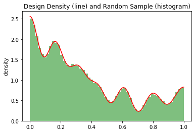

```python
# sanity check: plot to see if this actually works (seems pretty damn good :p)
x = np.linspace(0,1,10000)
y = f(x)
plt.figure()
plt.plot(x,y, color = 'r')
plt.hist(return_samples(100000),bins='auto', density = True, range=(x.min(),x.max()), color = 'g', alpha = 0.5)
plt.title("Design Density (line) and Random Sample (histogram)")
plt.ylabel("density")
plt.savefig('density_sample.pdf')
plt.show()
```